# Canopy arthropod declines along a gradient of olive farming intensification | Scientific Reports

# Canopy arthropod declines along a gradient of olive farming intensification

- Sasha Vasconcelos<sup>,,,</sup>,
- Sílvia Pina<sup>,</sup>,
- José M. Herrera<sup>,</sup>,
- Bruno Silva,
- Pedro Sousa,
- Miguel Porto<sup>,,</sup>,
- Nereida Melguizo-Ruiz,
- Gerardo Jiménez-Navarro,
- Sónia Ferreira<sup>,</sup>,
- Francisco Moreira<sup>,,</sup>,
- Ruben Heleno,
- Mattias Jonsson &
- …
- Pedro Beja<sup>,</sup>

[*Scientific Reports*](https://www.nature.com/srep) **volume 12**, Article number: 17273 (2022) Cite this article

## Abstract

Arthropod declines have been linked to agricultural intensification. However, information about the impacts of intensification is still limited for many crops, as is our understanding of the responses of different arthropod taxa and trophic groups, thus hindering the development of effective mitigation measures. We investigated the impacts of olive farming intensification on canopy-dwelling arthropods in the Mediterranean region. Intensification involves the increased use of agrochemicals, mechanisation and irrigation, but also structural changes from traditional orchards with low densities of large and old trees, to intensive and superintensive orchards with high to very high densities of smaller and younger trees, respectively. Canopy arthropods were vacuum-sampled at 53 sites representing the three orchard intensification levels, in spring, summer and autumn 2017. We evaluated how the arthropod community varied across intensification levels, and in response to orchard structure, management and landscape context. We found no changes in the diversity of arthropod taxa across intensification levels after correcting for sample coverage, but arthropod abundance declined markedly along the intensification gradient. Decreased abundance was associated with changes in orchard structure, lower herbaceous cover, and higher herbicide and insecticide use. The abundance of a specialized olive pest was lower in landscapes with higher woodland cover. The negative effects of intensification were stronger in spring and summer than in autumn, and parasitoids and predators were particularly affected. Overall, results suggest that retaining herbaceous cover, reducing agrochemical inputs and preserving natural woody elements in the landscape, may contribute to mitigate impacts of olive farming intensification on canopy arthropods, particularly on beneficial species.

## Introduction

Arthropods are declining in many terrestrial ecosystems<sup>1,2,3</sup>, posing a serious threat to ecosystem functioning and human wellbeing, given their key role in ecosystem processes and services<sup>4,5,6</sup>. Agricultural intensification is considered one of the main drivers of arthropod declines, both at local and landscape scales<sup>3,7</sup>. However, information about the impacts of intensification is still lacking for many crops. Moreover, little is known about whether different arthropod taxa and trophic groups are equally vulnerable to intensification<sup>3</sup>. Addressing these issues is thus critical to understand if and how intensified agriculture can be managed to mitigate negative impacts on arthropods.

Olive (*Olea europaea* L. 1753) is one of the crops that has rapidly expanded and intensified in recent decades, mainly due to a combination of agricultural policies and market mechanisms<sup>8,9</sup>. Cultivation of this crop is largely concentrated in the Mediterranean biodiversity hotspot<sup>10,11</sup>, where olive orchards have been part of rural landscapes for millennia<sup>12</sup> and harbour considerable arthropod diversity<sup>13,14</sup>. Traditional orchards are rain fed, typically composed of large and old trees (> 50 years) planted at low densities (ca. 100 trees ha<sup>−1</sup>), and are managed with reduced or no use of agrochemicals and mechanisation<sup>15,16</sup>. The soil is often tilled to remove vegetative cover between trees<sup>17,18</sup>, but a herbaceous layer may be retained under organic production models<sup>19,20</sup>. Over the past decades, these orchards have been replaced by larger and more intensively managed ones, that are irrigated, spray insecticides to control pests and herbicides to reduce the herbaceous layer, and have mechanical harvesting<sup>15,16</sup>. Intensification has also involved major changes in orchard structure, with intensive orchards characterized by high densities of relatively small and young trees (200–450 trees ha<sup>−1</sup>) planted at regular intervals, and superintensive orchards characterized by very high densities (1500–2000 trees ha<sup>−1</sup>) of dwarf tree varieties planted as hedgerows<sup>21,22</sup>. Despite ongoing intensification, these three levels of structural intensity still coexist at regional and even landscape levels<sup>9,23</sup>.

These changes, together with landscape simplification resulting from the ongoing expansion of intensified olive farming, are likely to have considerable impacts on arthropod diversity. Until now, however, most studies about the intensification of olive farming have focused on vertebrates, showing major declines in bat and breeding bird diversity and abundance from traditional, through intensive, to superintensive orchards<sup>24,25,26</sup>, and in response to increased landscape simplification<sup>25</sup>. Regarding arthropods, various studies have examined the effects of intensifying some management practices in olive orchards, showing that communities tend to be more diverse and/or abundant in orchards with reduced or no insecticide spraying, and where ground cover is present<sup>13,14,27,28,29,30</sup>. Some of these studies also explored the effects of landscape simplification on arthropods, reporting mostly negative, but also neutral or even positive effects<sup>14,29,30</sup>. However, detailed investigation of the effects of orchard structure on arthropods is still lacking, as previous studies were mostly carried out in orchards structurally similar to the traditional archetype, with none assessing superintensive orchards. This is an important aspect to consider as, for instance, large and old trees in traditional orchards might provide cavities and other refuges for a range of arthropod species<sup>31,32</sup>, which are generally absent in the younger and smaller trees of intensive and superintensive orchards. Therefore, examining the entire intensification gradient, while also considering changes in the landscape context, is essential to fully understand the impacts of olive farming intensification on arthropods.

Here, we examine how orchard- and landscape-level changes along an intensification gradient influence olive tree canopy-dwelling arthropod communities. We focused on canopy-dwelling arthropods, because they represent a complex community with a high diversity of taxonomic and functional groups and appear to be particularly sensitive to management practices in olive orchards<sup>13,27</sup>. We considered the overall community as well as functional trophic groups, because arthropod responses to disturbance might be strongly influenced by ecological traits<sup>33,34</sup>, in particular those related to feeding strategy<sup>35,36</sup>. The study was carried out from spring to autumn as arthropod responses are likely to vary due to seasonal changes in orchard management and weather conditions (e.g., rain and temperature). For instance, there might be stronger negative responses in periods with more concentrated insecticide use to control pests (e.g., olive moth on flowers in spring and olive fruit fly on olives in autumn)<sup>24</sup>. Likewise, greater resource availability in some seasons (e.g., more food and shelter associated with the herbaceous understory in spring) might differentially affect arthropod responses. Moreover, harsher weather in some seasons (e.g., hot and dry conditions in summer) could lead to more pronounced negative effects of intensification. Specifically, the goals of our study were to understand how the arthropod community varies across orchard intensification levels (traditional, intensive and superintensive), and in response to orchard structure, management and landscape context. Community variation was assessed in terms of (1) overall diversity and abundance, (2) diversity and abundance of trophic groups, and (3) abundance of individual taxa. We further examined (4) whether these responses varied across seasons.

## Material and methods

### Study area and sampling design

The study was conducted in the Alentejo region, southern Portugal (Fig. 1). The climate is Mediterranean, with mean daily temperatures ranging from 5.8 to 12.8 °C in winter and from 16.3 to 30.2 °C in summer<sup>37</sup>. Annual rainfall (500–600 mm) is largely limited to October–March. The landscape is mildly undulating (100–400 m a.s.l.) and dominated by open agricultural land, cork (*Quercus suber*) and holm oak (*Q. rotundifolia*) woodlands, olive orchards (*Olea europaea*) and vineyards (*Vitis vinifera*). In Alentejo, widespread intensification of olive farming has taken place in recent decades<sup>9</sup>, with the region currently accounting for ca. 75% of national olive production and containing approximately half of the Portuguese olive growing area (ca. 185,000 ha)<sup>38</sup>, including most of the recently established intensive and superintensive orchards (ca. 40,000 ha)<sup>39</sup>. Expansion of intensive olive farming in this area has been promoted by subsidies under the European Union Common Agricultural Policy (CAP), the increased market demand for olive oil, and the availability of new irrigation infrastructures<sup>9,40</sup>.

**Figure 1**

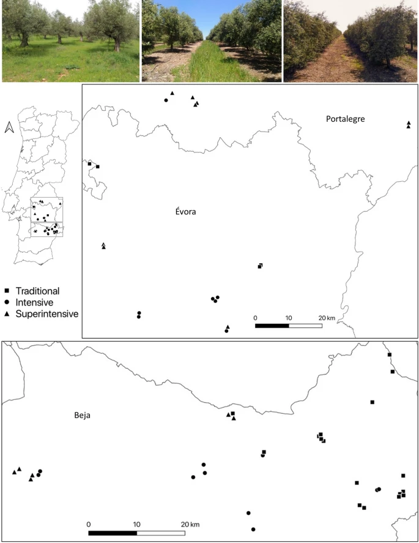

Location of the 53 points sampled for canopy-dwelling arthropods in traditional, intensive and superintensive orchards across the Alentejo region, southern Portugal. The two inset maps show the northern and southern sections of the study area in detail. Along the top are photographs representing traditional (left), intensive (middle) and superintensive (right) orchards. The maps were generated using the free and open source Geographic Information System QGIS v3.10 (https://qgis.org/en/site/).

[Full size image](https://www.nature.com/articles/s41598-022-21480-1/figures/1)

Sampling of canopy arthropods was made at points previously selected by Costa et al.<sup>25</sup>, following a stratified random procedure designed to represent the greatest possible range of variation in orchard structure. Initially, we selected 60 sampling points within 38 olive orchards across the study region, but excluded seven points located in three orchards that were largely unmanaged, and in two orchards for which no agrochemical information was obtained. A total of 53 points in 33 orchards was thus retained (Fig. 1). We established one point per orchard, except in the largest orchards where we established a maximum of three points at least 500 m apart. All points were placed as far as possible from orchard edges. Consent to carry out the study at the selected orchards was obtained from the respective land-owners and/or managers.

### Arthropod sampling

Canopy arthropods were vacuum sampled using a Modified CDC backpack aspirator model 1412 (John W. Hock Company, Gainsville, FL, USA). This method was chosen because it enables a rapid and efficient collection of canopy arthropods<sup>41</sup>, it provides data representative of arthropod community structure<sup>42</sup>, and has been extensively used for sampling olive tree canopies<sup>43,44,45</sup>. It should be noted, however, that vacuum sampling is less efficient for more mobile insects, including two of the major olive pests: olive moth (*Prays oleae*; Praydidae) and olive fruit fly (*Bactrocera oleae*; Tephritidae). Due to logistical constraints it was impractical to carry out the targeted sampling using traps or lures that are necessary to efficiently sample these insects<sup>46</sup>, and so results for families Praydidae and Tephritidae need to be interpreted with care. Sampling was carried out in spring (19 April–21 May), summer (14–29 June) and autumn (19 September–10 October) of 2017. This spans the periods of highest arthropod activity<sup>47</sup> and coincides with the olive tree’s flowering, fruit development and ripening stages<sup>48</sup>, respectively, when the main agrochemical treatments are undertaken<sup>24,49</sup>. In common with several other studies<sup>45,49,50,51</sup>, sampling could only be carried out in one year, which limits the power of the conclusions. However, despite potential interannual fluctuations in arthropod populations<sup>1,52</sup>, this timeframe was deemed reasonable as it is less likely that responses across orchard intensification levels also vary widely between years<sup>53,54</sup>. At each sampling point, five trees were marked, one located at the centre of the point and the other four at 20 m from the centre, approximately in the four cardinal directions. Each tree at each sampling point was aspirated once per season for one minute, yielding a total of 795 samples (53 sampling points × 5 trees × 3 seasons = 795 aspirations).

Specimens were stored in ethanol (70%) and subsequently identified to family level, because more detailed identification of every specimen was too time-consuming and/or impractical due to lack of taxonomic expertise. However, family-level identification can detect the effects of human-induced disturbance on terrestrial arthropod communities with little loss of information<sup>55,56,57</sup>. Nomenclature and taxonomy followed widely used entomological references<sup>58,59,60,61,62,63,64</sup>. Specimens from orders Ephemeroptera, Psocoptera, Thysanoptera and sub-order Nematocera could not be identified to family level, corresponding to 35.2% of 4665 collected arthropods. All arthropods successfully identified to family level (n = 3024) were assigned to one of four trophic groups based on their diets and feeding strategy: herbivores, predators, parasitoids and scavengers. Families reported to feed predominantly on arthropods, plant matter and dead matter and/or fungi, were classified as predators, herbivores and scavengers, respectively. Parasitoids have different feeding habits as larvae and adults, but were classified in a single separate group because of their parasitic nature. Chrysopidae also change their feeding habits during their life cycle but were classified as predators due to their importance as predators of olive tree pests<sup>65</sup>. Although the family Formicidae is composed of predator, scavenger and indirect herbivore species<sup>66</sup>, ants in olive tree canopies are mostly predatory<sup>67</sup> and were thus also classified as predators. An additional “mixed” category was created for arthropod families composed of species with a mixture of feeding strategies.

### Environmental variables

[Full size table](https://www.nature.com/articles/s41598-022-21480-1/tables/1)

[Full size table](https://www.nature.com/articles/s41598-022-21480-1/tables/2)

The potential effects of landscape context on local arthropod communities were also accounted for<sup>68,69</sup>, considering the percentage cover by dominant land uses in the region within a 500-m radius around each sampling point, namely: cork and holm oak woodlands, olive orchards, and open agricultural land<sup>26</sup>. This radius was selected because many arthropod taxa in olive orchards<sup>29,70</sup> and in other crops<sup>71</sup> are known to respond to landscape composition at this spatial scale. Due to intercorrelations between the cover by the dominant land use types, only cork and holm oak woodland cover was used in analyses (Table 2). These woodlands are highly biodiverse<sup>72</sup> and are the most widespread semi-natural habitat around olive orchards in southern Portugal<sup>73</sup>. Semi-natural habitats can act as sources of food, shelter, as well as breeding sites for numerous arthropods, including those that provide key services such as natural biocontrol<sup>68,69</sup>. Landscape composition was obtained in a Geographic Information System environment, from Portugal’s digital land cover map of 2015<sup>74</sup>, which was the date most closely matching the sampling year (2017).

### Data analysis

We estimated arthropod community diversity for each intensification level and season, using the Hill diversity framework<sup>75</sup> and the package iNEXT<sup>76</sup>, following Penado et al.<sup>77</sup>. To account for the effects of rarity on diversity estimates, we computed taxa richness (Hill number q = 0), and Hill-Shannon (q = 1) and Hill-Simpson (q = 2) diversities, because increasing the Hill number reduces the leverage of rare taxa<sup>75</sup>. Diversity estimates for a given intensification level were made by pooling all individuals collected at all sampling points across seasons, and then separately for each season. Estimates were made considering identifications to the highest possible taxonomic resolution, that is, family level except for orders Ephemeroptera, Psocoptera, Thysanoptera and sub-order Nematocera. Because diversity metrics are sensitive to sampling effort and relative abundance, we standardised diversity estimates to equal-coverage<sup>75,77</sup>, with coverage estimating the proportion of individuals in the (whole) community that belong to the taxa present in the sample<sup>75</sup>. To standardise diversity estimates, we first assessed variation in sample coverage with increasing number of individuals identified, and then set a fixed coverage value, corresponding to the minimum coverage obtained when each sample (traditional, intensive, superintensive) is extrapolated to double the number of individuals identified<sup>75,77</sup>. Diversity estimates (± 95% Confidence Intervals) were obtained at the fixed coverage value, either by extrapolation for samples with coverage lower than the standard value, or through rarefaction otherwise<sup>75,77</sup>.

We then examined the effects of intensification on community- and taxon-level abundance, and how such effects depend on ecological traits, using the Hierarchical Modelling of Species Communities (HMSC) framework<sup>78</sup>. Although HMSC also produces estimates of community richness, these were not used because they are uncorrected for sample coverage, and can thus be highly influenced by the number of individuals collected at each sampling point. HMSC is a class of hierarchical Bayesian joint species distribution models that relate community- and taxon-level responses to environmental covariates, while determining whether responses are influenced by taxon traits and also accounting for random effects related to study design and spatial dependencies<sup>78</sup>. For the analyses, we built a community matrix (sites/orchard/season × taxa<sub>*all*</sub>) pooling data for each arthropod taxon (orders/sub-orders and families) from the five replicate olive trees per sampling point per season. We then built a second community matrix (sites/orchard/season × taxa<sub>*families*</sub>) where only data at family level were used, thereby excluding Ephemeroptera, Psocoptera, Thysanoptera, and sub-order Nematocera. The environmental matrix (sites/season × covariates) was built considering as covariates the orchard intensification levels, their structural, management and landscape variables (Tables 1, 2), and season (spring, summer, autumn) depending on the particular analysis performed (see below). The trait matrix (taxa × traits) was built considering the assignment of each arthropod family to one of the five trophic groups. We also considered a matrix of site coordinates to account for spatial dependencies<sup>78</sup>.

In model building, we used abundance (count) community matrices as response variables, assuming a lognormal Poisson distribution and log-link function to allow for more variation around the expectation<sup>78</sup>. We used the first community matrix (sites/orchard/season × taxa<sub>*all*</sub>) and the environmental matrix to build an initial model considering only season and orchard intensification levels, as well as their interaction terms, to evaluate broad changes in community patterns along the intensity gradient over the seasons. We then built a second model using structural, management and landscape covariates, and their interactions with season, thereby evaluating community responses to different aspects of intensification and whether responses varied seasonally. The structural variables were all correlated, therefore, we only retained trunk diameter at breast height (dbh) to avoid multicollinearity<sup>79</sup>. This variable was selected because it was the most strongly correlated with the first dimension of the PCA (Supplementary Table S1), which accounted for 76.4% of the variation in orchard structure (Supplementary Fig. S2). Irrigation was dropped from the analysis because it was strongly correlated with dbh (r = − 0.916, *P* < 0.001). Although the correlation between dbh and insecticide use was also high (r =− 0.648, *P* < 0.001), they were both retained because the value was below the threshold of r = 0.7<sup>79</sup> (Supplementary Table S2). In all the models we included an orchard-level random effect to account for similar management practices in sampling points belonging to the same orchard, a site-level random effect to control for repeated visits to the same sampling point, and the matrix of site coordinates for spatial dependencies. We subsequently repeated the entire process, using the second community matrix (sites/orchard/season × taxa<sub>*families*</sub>) together with the trait matrix, to evaluate changes in trophic group responses along the intensification gradient across seasons. The fitted models were used to predict abundance for the overall community and for each trophic group, by summing the corresponding predicted abundance of individual taxa. Statistical support for differences in arthropod abundance between orchard intensification levels, and in response to structural, management and landscape variables, was assessed from the overlap between 84% credible intervals (CI). These intervals more adequately approximate an α = 0.05 error rate, while comparisons using 95% intervals are overly conservative<sup>80</sup>. Non-overlapping CIs thus provide statistical support for differences at α ~ 0.05<sup>80</sup>.

Models were fitted to the data with the HMSC-R package<sup>81</sup> for R<sup>82</sup>. Each model was run with five Markov chains for 250,000 iterations, from which the first 150,000 were discarded as transient. We assessed model convergence by inspecting the trace plots of β estimates and the width of credible intervals of model estimates, discarding rare taxa (< 10 individuals) as this improved convergence. The models’ explanatory power was evaluated using *R*<sup>2</sup><sup>2,81</sup>.